# Anexos. Tesina

Francisco Nagib Ruiz Reyes

2022-06-13

Se establece la ruta de trabajo

```r
setwd("C:/Users/Scarl/Dropbox/Maestría ITESM/Tesina/Rstudio")
```

Leemos el archivo y se crea un Dataframe

```r
petroleo <- read.csv(file='Resumen_petroleo.csv')
petroleo <- data.frame(petroleo, start = c(1996,1), frequency = 12)
```

Se cargan paquterías

```r
library(tseries)
library(forecast)
library(vars)
library(ggfortify)
library(vars)
library(ggfortify)
library(fUnitRoots)
library(lmtest)
library(ARDL)
```

Se sacan el logaritmo a las variables

```r
MM_ln <- log(petroleo$MM)
WTI_ln <- log(petroleo$WTI)
BRENT_ln <- log(petroleo$BRENT)
DJI_ln <- log(petroleo$DJI)
XAU_ln <- log(petroleo$XAU)
OILC1_ln <- log(petroleo$OILC1)
```

Se hace una diferenciación

```r
MM_ln_diff <- diff(MM_ln, lag = 1)
WTI_ln_diff <- diff(WTI_ln, lag = 1)
BRENT_ln_diff <- diff(BRENT_ln, lag = 1)
DJI_ln_diff <- diff(DJI_ln, lag =  1)
XAU_ln_diff <- diff(XAU_ln, lag = 1)
OILC1_ln_diff <- diff(OILC1_ln, lag = 1)
```

Creamos un nuevo Dataframe

```r
petroleo_ln <- data.frame(MM_ln,WTI_ln,BRENT_ln, DJI_ln, XAU_ln, OILC1_ln)
petroleo_diff<- data.frame(MM_ln_diff,WTI_ln_diff,BRENT_ln_diff, DJI_ln_diff, XAU_ln_diff, OILC1_ln_diff)
```

Los pasamos a Series de tiempo

```r
ln_ts <- ts(data = petroleo_ln, start = c(1996,1), frequency = 12)
head(ln_ts)
```

```
##             MM_ln   WTI_ln BRENT_ln   DJI_ln   XAU_ln OILC1_ln
## Jan 1996 2.716018 2.876949 2.811208 8.593283 6.007461 2.875822
## Feb 1996 2.822569 2.975019 2.933857 8.609885 5.990839 2.972464
## Mar 1996 2.909630 3.064792 3.012098 8.628223 5.980024 3.066657
## Apr 1996 2.868467 3.042139 2.970414 8.624983 5.970369 3.054001
## May 1996 2.802148 2.984166 2.895912 8.638201 5.968708 2.983660
## Jun 1996 2.858766 3.040706 2.959068 8.640228 5.941355 3.040706
```

Graficamos las series de tiempo

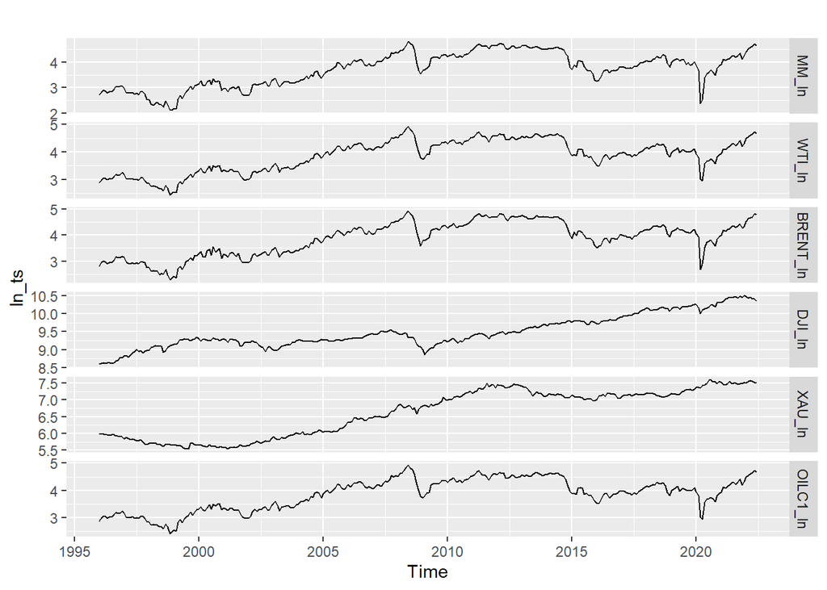

```r
autoplot(ln_ts, facets = TRUE)
```

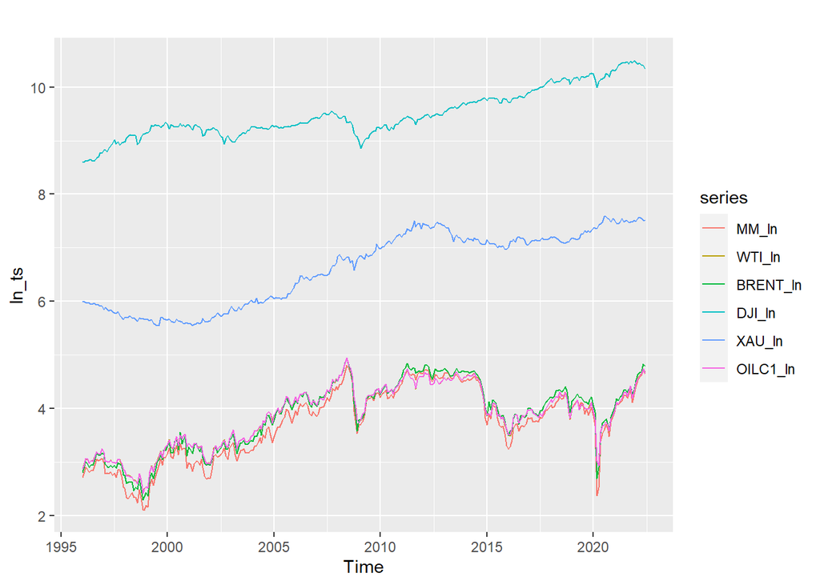

```r
autoplot(ln_ts, facets = FALSE)
```

Hacemos los modelos de regresión Multiple

```r
#Todas las Variables
model_reg <- lm(formula =  MM_ln_diff ~  WTI_ln_diff + BRENT_ln_diff + DJI_ln_diff +XAU_ln_diff + OILC1_ln_diff -1, data=petroleo_diff)
model_reg
```

```
##
## Call:
## lm(formula = MM_ln_diff ~ WTI_ln_diff + BRENT_ln_diff + DJI_ln_diff +
##     XAU_ln_diff + OILC1_ln_diff - 1, data = petroleo_diff)
##
## Coefficients:
##   WTI_ln_diff  BRENT_ln_diff    DJI_ln_diff    XAU_ln_diff  OILC1_ln_diff
##      -0.10539        0.67676        0.08849        0.06966        0.54758
```

```r
summary(model_reg)
```

```
##
## Call:
## lm(formula = MM_ln_diff ~ WTI_ln_diff + BRENT_ln_diff + DJI_ln_diff +
##     XAU_ln_diff + OILC1_ln_diff - 1, data = petroleo_diff)
##
## Residuals:
##       Min        1Q    Median        3Q       Max
## -0.155177 -0.020079 -0.002739  0.016600  0.154329
##
## Coefficients:
##               Estimate Std. Error t value Pr(>|t|)
## WTI_ln_diff   -0.10539    0.19940  -0.529  0.59750
## BRENT_ln_diff  0.67676    0.03513  19.265  < 2e-16 ***
## DJI_ln_diff    0.08849    0.04705   1.881  0.06093 .
## XAU_ln_diff    0.06966    0.04354   1.600  0.11067
## OILC1_ln_diff  0.54758    0.19699   2.780  0.00577 **
## ---
## Signif. codes:  0 '***' 0.001 '**' 0.01 '*' 0.05 '.' 0.1 ' ' 1
##
## Residual standard error: 0.03511 on 312 degrees of freedom
## Multiple R-squared:  0.9396, Adjusted R-squared:  0.9386
## F-statistic: 970.3 on 5 and 312 DF,  p-value: < 2.2e-16
```

```r
#Probamos otra vez eliminando WTI
model_reg_2 <- lm(formula =  MM_ln_diff ~  BRENT_ln_diff + DJI_ln_diff +XAU_ln_diff + OILC1_ln_diff-1, data=petroleo_diff)
model_reg_2
```

```
##
## Call:
## lm(formula = MM_ln_diff ~ BRENT_ln_diff + DJI_ln_diff + XAU_ln_diff +
##     OILC1_ln_diff - 1, data = petroleo_diff)
##
## Coefficients:
## BRENT_ln_diff    DJI_ln_diff    XAU_ln_diff  OILC1_ln_diff
##       0.67454        0.08693        0.06900        0.44584
```

```r
summary(model_reg_2)
```

```
##
## Call:
## lm(formula = MM_ln_diff ~ BRENT_ln_diff + DJI_ln_diff + XAU_ln_diff +
##     OILC1_ln_diff - 1, data = petroleo_diff)
##
## Residuals:
##       Min        1Q    Median        3Q       Max
## -0.155652 -0.019755 -0.002542  0.016622  0.155430
##
## Coefficients:
##               Estimate Std. Error t value Pr(>|t|)
## BRENT_ln_diff  0.67454    0.03484  19.363   <2e-16 ***
## DJI_ln_diff    0.08693    0.04690   1.853   0.0648 .
## XAU_ln_diff    0.06900    0.04348   1.587   0.1135
## OILC1_ln_diff  0.44584    0.04181  10.663   <2e-16 ***
## ---
## Signif. codes:  0 '***' 0.001 '**' 0.01 '*' 0.05 '.' 0.1 ' ' 1
##
## Residual standard error: 0.03507 on 313 degrees of freedom
## Multiple R-squared:  0.9395, Adjusted R-squared:  0.9388
## F-statistic:  1216 on 4 and 313 DF,  p-value: < 2.2e-16
```

```r
#Probamos otra vez eliminando XAU
model_reg_3 <- lm(formula =  MM_ln_diff ~  BRENT_ln_diff + DJI_ln_diff  + OILC1_ln_diff-1, data=petroleo_diff)
model_reg_3
```

```
##
## Call:
## lm(formula = MM_ln_diff ~ BRENT_ln_diff + DJI_ln_diff + OILC1_ln_diff -
##     1, data = petroleo_diff)
##
## Coefficients:
## BRENT_ln_diff    DJI_ln_diff  OILC1_ln_diff
##       0.67288        0.08464        0.45244
```

```r
summary(model_reg_3)
```

```
##
## Call:
## lm(formula = MM_ln_diff ~ BRENT_ln_diff + DJI_ln_diff + OILC1_ln_diff -
##     1, data = petroleo_diff)
##
## Residuals:
##       Min        1Q    Median        3Q       Max
## -0.153686 -0.019483 -0.003172  0.016430  0.154272
##
## Coefficients:
##               Estimate Std. Error t value Pr(>|t|)
## BRENT_ln_diff  0.67288    0.03491  19.277   <2e-16 ***
## DJI_ln_diff    0.08464    0.04699   1.801   0.0726 .
## OILC1_ln_diff  0.45244    0.04171  10.848   <2e-16 ***
## ---
## Signif. codes:  0 '***' 0.001 '**' 0.01 '*' 0.05 '.' 0.1 ' ' 1
##
## Residual standard error: 0.03516 on 314 degrees of freedom
## Multiple R-squared:  0.939,  Adjusted R-squared:  0.9385
## F-statistic:  1612 on 3 and 314 DF,  p-value: < 2.2e-16
```

Dejando solo BRENT y OILC1, tenemos que, todas las variables son significativa.

```r
model_reg_4 <- lm(formula =  MM_ln_diff ~  BRENT_ln_diff  + OILC1_ln_diff-1, data=petroleo_diff)
model_reg_4
```

```
##
## Call:
## lm(formula = MM_ln_diff ~ BRENT_ln_diff + OILC1_ln_diff - 1,
##     data = petroleo_diff)
##
## Coefficients:
## BRENT_ln_diff  OILC1_ln_diff
##        0.6763         0.4582
```

```r
summary(model_reg_4)
```

```
##
## Call:
## lm(formula = MM_ln_diff ~ BRENT_ln_diff + OILC1_ln_diff - 1,
##     data = petroleo_diff)
##
## Residuals:
##       Min        1Q    Median        3Q       Max
## -0.151557 -0.020219 -0.001167  0.016621  0.151972
##
## Coefficients:
##               Estimate Std. Error t value Pr(>|t|)
## BRENT_ln_diff  0.67634    0.03498   19.34   <2e-16 ***
## OILC1_ln_diff  0.45818    0.04173   10.98   <2e-16 ***
## ---
## Signif. codes:  0 '***' 0.001 '**' 0.01 '*' 0.05 '.' 0.1 ' ' 1
##
## Residual standard error: 0.03528 on 315 degrees of freedom
## Multiple R-squared:  0.9384, Adjusted R-squared:  0.938
## F-statistic:  2400 on 2 and 315 DF,  p-value: < 2.2e-16
```

Descomponemos la serie de tiempo

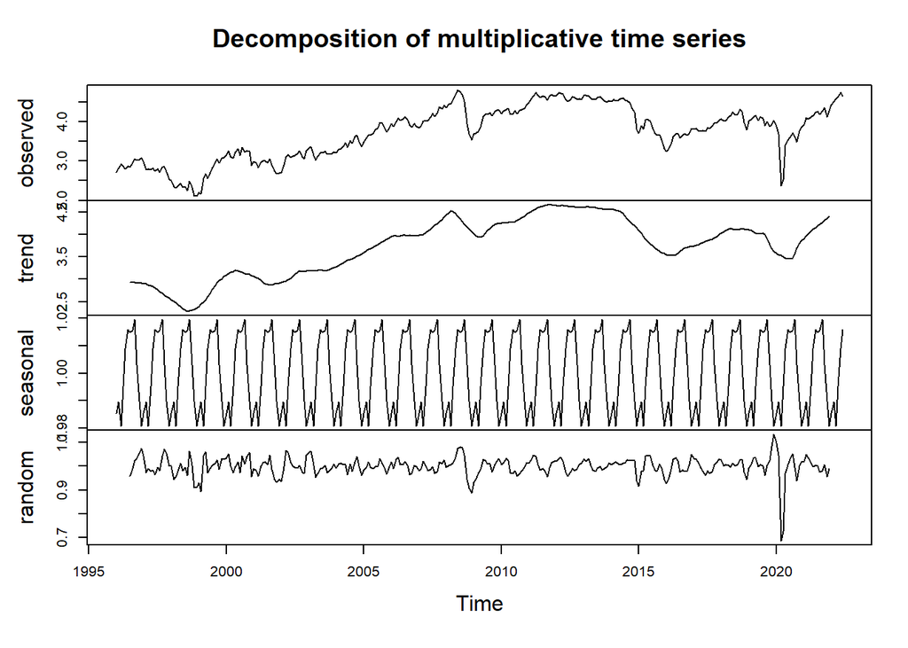

```r
ln_ts_MM <- ts(data = MM_ln, start = c(1996,1), frequency = 12)
componentes = decompose(ln_ts_MM, type = c("multiplicative"))
plot(componentes)
```

Diferenciamos

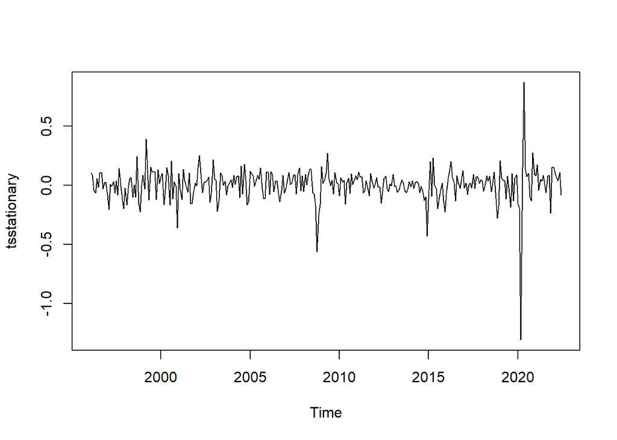

```r
tsstationary = diff(ln_ts_MM, differences=1)
plot(tsstationary)
```

```r
adf.test(tsstationary, k =4)
```

```
##
##  Augmented Dickey-Fuller Test
##
## data:  tsstationary
## Dickey-Fuller = -8.9458, Lag order = 4, p-value = 0.01
## alternative hypothesis: stationary
```

Obtenemos autocorrelación y autocorrelación parcial

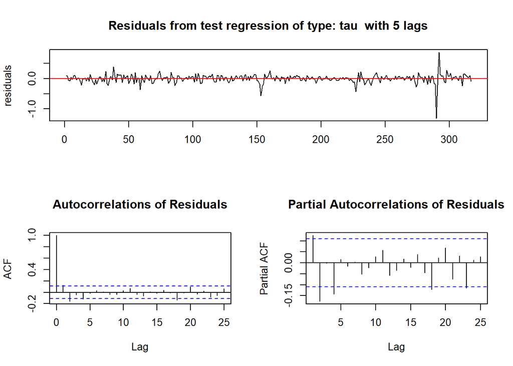

```
##
## Title:
##  KPSS Unit Root Test
##
## Test Results:
##   NA
##
## Description:
##  Sun Nov 13 23:33:59 2022 by user: Scarl
```

```r
urkpssTest(tsstationary, type = c("tau"), lags = c("short"),use.lag = NULL, doplot = TRUE)
```

Primero vemos el modelo con un auto.arima

```r
arima_automa <- auto.arima(petroleo_ln$MM_ln)
summary(arima_automa)
```

```
## Series: petroleo_ln$MM_ln
## ARIMA(0,1,2)
##
## Coefficients:
##          ma1      ma2
##       0.1522  -0.1994
## s.e.  0.0565   0.0616
##
## sigma^2 = 0.01911:  log likelihood = 178.38
## AIC=-350.76   AICc=-350.68   BIC=-339.48
##
## Training set error measures:
##                       ME      RMSE        MAE        MPE     MAPE     MASE
## Training set 0.006331838 0.1375988 0.09109922 0.07763986 2.659374 0.994705
##                     ACF1
## Training set 0.002388599
```

Probamos ARIMA. con configuración de ARIMA (4,1,4) y estacional (3,0,3)

```r
fitARIMA_4r <- arima(ln_ts_MM, order=c(4,1,4),seasonal = list(order = c(3,0,3), period = 12),method="ML")
summary(fitARIMA_4r)
```

```
##
## Call:
## arima(x = ln_ts_MM, order = c(4, 1, 4), seasonal = list(order = c(3, 0, 3),
##     period = 12), method = "ML")
##
## Coefficients:
##          ar1      ar2     ar3     ar4      ma1     ma2      ma3      ma4
##       0.6234  -0.8146  0.2822  0.1577  -0.4863  0.6128  -0.0830  -0.4448
## s.e.  0.0931   0.0366  0.0652  0.0147   0.2370  0.3424   0.1343   0.3338
##          sar1    sar2    sar3    sma1     sma2     sma3
##       -0.2432  0.2528  0.9777  0.2790  -0.2872  -0.9508
## s.e.   0.0710  0.0743  0.0007  0.1558   0.2158   0.0758
##
## sigma^2 estimated as 0.01657:  log likelihood = 190.59,  aic = -351.18
##
## Training set error measures:
##                      ME      RMSE        MAE       MPE     MAPE      MASE
## Training set 0.00555232 0.1285266 0.08654335 0.0644274 2.514484 0.9449598
##                      ACF1
## Training set -0.000180712
```

```r
coeftest(fitARIMA_4r)
```

```
##
## z test of coefficients:
##
##         Estimate  Std. Error   z value  Pr(>|z|)
## ar1   0.62337183  0.09312634    6.6938 2.174e-11 ***
## ar2  -0.81458412  0.03657845  -22.2695 < 2.2e-16 ***
## ar3   0.28216957  0.06522695    4.3260 1.519e-05 ***
## ar4   0.15767236  0.01466731   10.7499 < 2.2e-16 ***
## ma1  -0.48626650  0.23704972   -2.0513 0.0402351 *
## ma2   0.61282772  0.34242383    1.7897 0.0735060 .
## ma3  -0.08303857  0.13426603   -0.6185 0.5362702
## ma4  -0.44479221  0.33376855   -1.3326 0.1826511
## sar1 -0.24315450  0.07096796   -3.4263 0.0006120 ***
## sar2  0.25283246  0.07430642    3.4026 0.0006676 ***
## sar3  0.97774798  0.00072775 1343.5178 < 2.2e-16 ***
## sma1  0.27902076  0.15575749    1.7914 0.0732324 .
## sma2 -0.28721002  0.21583790   -1.3307 0.1832961
## sma3 -0.95083523  0.07575906  -12.5508 < 2.2e-16 ***
## ---
## Signif. codes:  0 '***' 0.001 '**' 0.01 '*' 0.05 '.' 0.1 ' ' 1
```

```r
#Vemos significancia en niveles de 4 rezagos.
```

Probamos ARIMA. con configuración de ARIMA (3,1,3) y estacional (2,0,2)

```r
fitARIMA_3r <- arima(ln_ts_MM, order=c(3,1,3),seasonal = list(order = c(2,0,2), period = 12),method="ML")
summary(fitARIMA_3r)
```

```
##
## Call:
## arima(x = ln_ts_MM, order = c(3, 1, 3), seasonal = list(order = c(2, 0, 2),
##     period = 12), method = "ML")
##
## Coefficients:
##          ar1     ar2      ar3      ma1      ma2     ma3     sar1     sar2
##       0.4990  0.2452  -0.2278  -0.3480  -0.4806  0.2259  -1.2485  -0.9923
## s.e.  0.7121  0.3641   0.2892   0.7137   0.2739  0.4200   0.0429   0.0167
##         sma1    sma2
##       1.2769  0.9924
## s.e.  0.1025  0.1162
##
## sigma^2 estimated as 0.01731:  log likelihood = 184.5,  aic = -346.99
##
## Training set error measures:
##                       ME      RMSE        MAE       MPE     MAPE      MASE
## Training set 0.006815308 0.1313749 0.08776366 0.0905502 2.558357 0.9582843
##                      ACF1
## Training set -0.003422059
```

```r
coeftest(fitARIMA_3r)
```

```
##
## z test of coefficients:
##
##       Estimate Std. Error  z value Pr(>|z|)
## ar1   0.498962   0.712145   0.7006  0.48352
## ar2   0.245199   0.364114   0.6734  0.50068
## ar3  -0.227823   0.289202  -0.7878  0.43083
## ma1  -0.348037   0.713738  -0.4876  0.62582
## ma2  -0.480634   0.273924  -1.7546  0.07932 .
## ma3   0.225870   0.420025   0.5378  0.59075
## sar1 -1.248467   0.042863 -29.1270  < 2e-16 ***
## sar2 -0.992256   0.016687 -59.4624  < 2e-16 ***
## sma1  1.276853   0.102520  12.4546  < 2e-16 ***
## sma2  0.992359   0.116192   8.5407  < 2e-16 ***
## ---
## Signif. codes:  0 '***' 0.001 '**' 0.01 '*' 0.05 '.' 0.1 ' ' 1
```

Ahora tomamos el Modelo ARDL Dado que en la regresión anterior tenemos WTI y BRENT pero BRENT es significativo, eliminamos WTI.

```r
ardl_24000 <- ardl( MM_ln ~ BRENT_ln + DJI_ln +XAU_ln + OILC1_ln -1 , data = petroleo_ln, order = c(2,4,0,0,0))
summary(ardl_24000)
```

```
##
## Time series regression with "ts" data:
## Start = 5, End = 318
##
## Call:
## dynlm::dynlm(formula = full_formula, data = data, start = start,
##     end = end)
##
## Residuals:
##       Min        1Q    Median        3Q       Max
## -0.105519 -0.024562  0.002319  0.021188  0.117595
##
## Coefficients:
##                 Estimate Std. Error t value Pr(>|t|)
## L(MM_ln, 1)     0.650932   0.055814  11.663  < 2e-16 ***
## L(MM_ln, 2)     0.106007   0.055366   1.915 0.056474 .
## BRENT_ln        0.934032   0.031720  29.446  < 2e-16 ***
## L(BRENT_ln, 1) -0.600378   0.059490 -10.092  < 2e-16 ***
## L(BRENT_ln, 2) -0.201561   0.057310  -3.517 0.000503 ***
## L(BRENT_ln, 3)  0.041154   0.023750   1.733 0.084151 .
## L(BRENT_ln, 4) -0.038548   0.016364  -2.356 0.019127 *
## DJI_ln         -0.026118   0.004549  -5.742 2.27e-08 ***
## XAU_ln          0.033906   0.007488   4.528 8.56e-06 ***
## OILC1_ln        0.104989   0.033358   3.147 0.001811 **
## ---
## Signif. codes:  0 '***' 0.001 '**' 0.01 '*' 0.05 '.' 0.1 ' ' 1
##
## Residual standard error: 0.03645 on 304 degrees of freedom
## Multiple R-squared:  0.9999, Adjusted R-squared:  0.9999
## F-statistic: 3.404e+05 on 10 and 304 DF,  p-value: < 2.2e-16
```

```r
#Vemos significancia en el 4 rezago.
```

Dado que tenemos WTI y BRENT pero BRENT es significativo, eliminamos WTI. (Ya no se ve significancia en 5)

```r
ardl_25000 <- ardl( MM_ln ~ BRENT_ln + DJI_ln +XAU_ln + OILC1_ln-1, data = petroleo_ln, order = c(2,5,0,0,0))
summary(ardl_25000)
```

```
##
## Time series regression with "ts" data:
## Start = 6, End = 318
##
## Call:
## dynlm::dynlm(formula = full_formula, data = data, start = start,
##     end = end)
##
## Residuals:
##       Min        1Q    Median        3Q       Max
## -0.107737 -0.024439  0.001657  0.020937  0.115517
##
## Coefficients:
##                 Estimate Std. Error t value Pr(>|t|)
## L(MM_ln, 1)     0.658581   0.056649  11.626  < 2e-16 ***
## L(MM_ln, 2)     0.104593   0.055494   1.885 0.060425 .
## BRENT_ln        0.933350   0.031899  29.260  < 2e-16 ***
## L(BRENT_ln, 1) -0.606991   0.060122 -10.096  < 2e-16 ***
## L(BRENT_ln, 2) -0.202196   0.057425  -3.521 0.000496 ***
## L(BRENT_ln, 3)  0.043992   0.024029   1.831 0.068118 .
## L(BRENT_ln, 4) -0.052535   0.023176  -2.267 0.024112 *
## L(BRENT_ln, 5)  0.014253   0.016376   0.870 0.384795
## DJI_ln         -0.025362   0.004633  -5.474 9.28e-08 ***
## XAU_ln          0.032355   0.007693   4.206 3.44e-05 ***
## OILC1_ln        0.104641   0.033478   3.126 0.001947 **
## ---
## Signif. codes:  0 '***' 0.001 '**' 0.01 '*' 0.05 '.' 0.1 ' ' 1
##
## Residual standard error: 0.03652 on 302 degrees of freedom
## Multiple R-squared:  0.9999, Adjusted R-squared:  0.9999
## F-statistic: 3.077e+05 on 11 and 302 DF,  p-value: < 2.2e-16
```

Dado que tenemos WTI y BRENT pero BRENT es significativo, eliminamos WTI. (Ya no vemos significancia en XAU, XJI y OILC1 con rezagos mayores a 1)

```r
ardl_25111 <- ardl( MM_ln ~ BRENT_ln + DJI_ln +XAU_ln + OILC1_ln-1, data = petroleo_ln, order = c(2,4,2,2,2))
summary(ardl_25111)
```

```
##
## Time series regression with "ts" data:
## Start = 5, End = 318
##
## Call:
## dynlm::dynlm(formula = full_formula, data = data, start = start,
##     end = end)
##
## Residuals:
##       Min        1Q    Median        3Q       Max
## -0.124374 -0.018578 -0.000237  0.017671  0.106578
##
## Coefficients:
##                Estimate Std. Error t value Pr(>|t|)
## L(MM_ln, 1)     0.76798    0.05783  13.281  < 2e-16 ***
## L(MM_ln, 2)     0.02838    0.05642   0.503   0.6153
## BRENT_ln        0.74125    0.03913  18.943  < 2e-16 ***
## L(BRENT_ln, 1) -0.44432    0.05775  -7.694 2.10e-13 ***
## L(BRENT_ln, 2) -0.10365    0.05580  -1.858   0.0642 .
## L(BRENT_ln, 3)  0.03158    0.02209   1.430   0.1537
## L(BRENT_ln, 4) -0.02347    0.01506  -1.559   0.1201
## DJI_ln          0.08759    0.04606   1.902   0.0582 .
## L(DJI_ln, 1)   -0.14523    0.06378  -2.277   0.0235 *
## L(DJI_ln, 2)    0.04270    0.04624   0.923   0.3566
## XAU_ln          0.05085    0.04196   1.212   0.2265
## L(XAU_ln, 1)    0.03883    0.05576   0.696   0.4867
## L(XAU_ln, 2)   -0.07080    0.04252  -1.665   0.0969 .
## OILC1_ln        0.35898    0.04733   7.585 4.27e-13 ***
## L(OILC1_ln, 1) -0.38855    0.05634  -6.897 3.18e-11 ***
## L(OILC1_ln, 2)  0.02791    0.05204   0.536   0.5921
## ---
## Signif. codes:  0 '***' 0.001 '**' 0.01 '*' 0.05 '.' 0.1 ' ' 1
##
## Residual standard error: 0.03288 on 298 degrees of freedom
## Multiple R-squared:  0.9999, Adjusted R-squared:  0.9999
## F-statistic: 2.614e+05 on 16 and 298 DF,  p-value: < 2.2e-16
```

```r
ardl_240000 <- ardl( MM_ln ~  BRENT_ln + DJI_ln +XAU_ln + OILC1_ln + WTI_ln-1, data = petroleo_ln, order = c(2,4,0,0,0,0))
summary(ardl_240000)
```

```
##
## Time series regression with "ts" data:
## Start = 5, End = 318
##
## Call:
## dynlm::dynlm(formula = full_formula, data = data, start = start,
##     end = end)
##
## Residuals:
##       Min        1Q    Median        3Q       Max
## -0.105571 -0.024591  0.002449  0.021145  0.117387
##
## Coefficients:
##                 Estimate Std. Error t value Pr(>|t|)
## L(MM_ln, 1)     0.651110   0.055937  11.640  < 2e-16 ***
## L(MM_ln, 2)     0.105811   0.055496   1.907 0.057510 .
## BRENT_ln        0.933867   0.031821  29.348  < 2e-16 ***
## L(BRENT_ln, 1) -0.600311   0.059591 -10.074  < 2e-16 ***
## L(BRENT_ln, 2) -0.201678   0.057417  -3.512 0.000512 ***
## L(BRENT_ln, 3)  0.041229   0.023803   1.732 0.084271 .
## L(BRENT_ln, 4) -0.038587   0.016396  -2.353 0.019242 *
## DJI_ln         -0.026167   0.004586  -5.706 2.75e-08 ***
## XAU_ln          0.033986   0.007548   4.503 9.59e-06 ***
## OILC1_ln        0.078419   0.285829   0.274 0.783996
## WTI_ln          0.026747   0.285770   0.094 0.925491
## ---
## Signif. codes:  0 '***' 0.001 '**' 0.01 '*' 0.05 '.' 0.1 ' ' 1
##
## Residual standard error: 0.03651 on 303 degrees of freedom
## Multiple R-squared:  0.9999, Adjusted R-squared:  0.9999
## F-statistic: 3.084e+05 on 11 and 303 DF,  p-value: < 2.2e-16
```

Resumen: Encontramos niveles significativos en el cuarto rezago.